# Exercise week 10

Shawn Schneidereit

2021-06-20

The data contained in library(MASS);data(eagles) are records of salmon pirating at- tempts by Bald Eagles in Washington State. See ?eagles for details. While one eagle feeds, some- times another will swoop in and try to steal the salmon from it. Call the feeding eagle the “victim” and the thief the “pirate.” Use the available data to build a binomial GLM of successful pirating attempts.

```r
library(MASS)
data(eagles, package = "MASS")
data <- eagles
?eagles

# Creating dummy variables
data$pirate_L <- ifelse(data$P == "L", 1, 0)
data$victim_L <- ifelse(data$V == "L", 1, 0)
data$pirate_A <- ifelse(data$A == "A", 1, 0)
str(data)
```

```
## 'data.frame':    8 obs. of  8 variables:
##  $ y       : int  17 29 17 20 1 15 0 1
##  $ n       : int  24 29 27 20 12 16 28 4
##  $ P       : Factor w/ 2 levels "L","S": 1 1 1 1 2 2 2 2
##  $ A       : Factor w/ 2 levels "A","I": 1 1 2 2 1 1 2 2
##  $ V       : Factor w/ 2 levels "L","S": 1 2 1 2 1 2 1 2
##  $ pirate_L: num  1 1 1 1 0 0 0 0
##  $ victim_L: num  1 0 1 0 1 0 1 0
##  $ pirate_A: num  1 1 0 0 1 1 0 0
```

### Q11H2a

Fit the model above to the eagles data, using brms. Is the approximation okay?

```r
b11.h2 <-
  brm(data = data,
      family = binomial,
      y | trials(n) ~ 1 + pirate_L + victim_L + pirate_A,
      prior = c(prior(normal(0, 1.5), class = Intercept),
                prior(normal(0, 0.5), class = b)),
      iter = 2000, warmup = 1000, chains = 4, cores = 4,
      seed = 11)
```

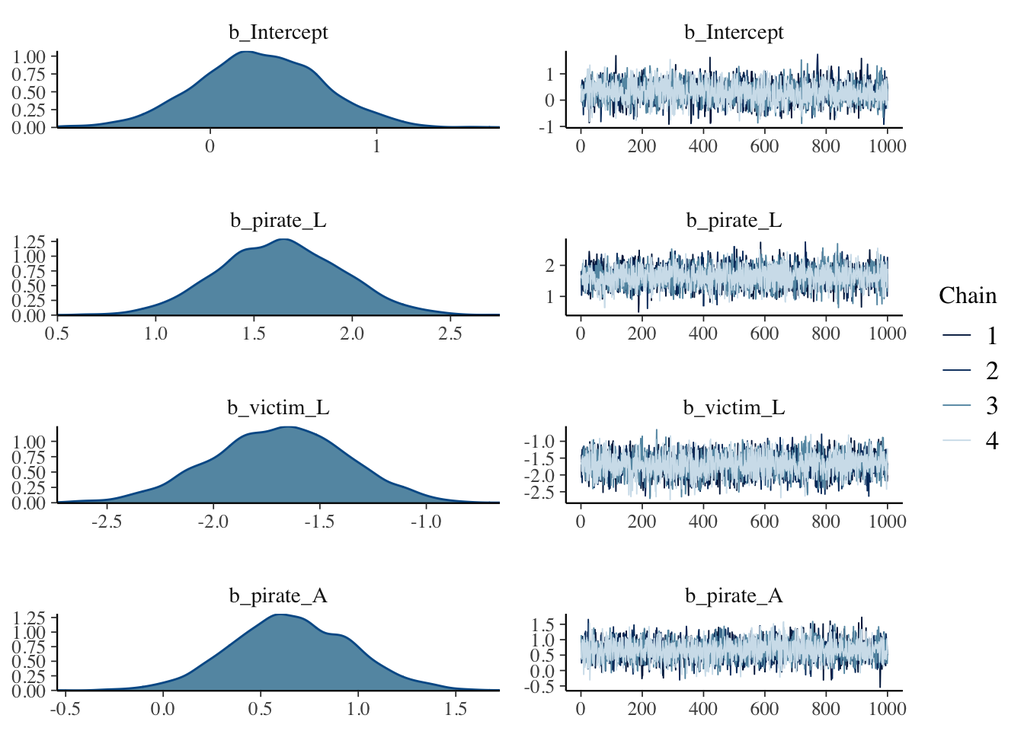

```r
plot(b11.h2)
```

```r
summary(b11.h2)
```

```
##  Family: binomial
##   Links: mu = logit
## Formula: y | trials(n) ~ 1 + pirate_L + victim_L + pirate_A
##    Data: data (Number of observations: 8)
## Samples: 4 chains, each with iter = 2000; warmup = 1000; thin = 1;
##          total post-warmup samples = 4000
##
## Population-Level Effects:
##           Estimate Est.Error l-95% CI u-95% CI Rhat Bulk_ESS Tail_ESS
## Intercept     0.30      0.38    -0.45     1.03 1.00     3146     2831
## pirate_L      1.63      0.31     1.03     2.25 1.00     4125     3236
## victim_L     -1.69      0.32    -2.32    -1.09 1.00     3500     2909
## pirate_A      0.66      0.31     0.06     1.27 1.00     4184     2927
##
## Samples were drawn using sampling(NUTS). For each parameter, Bulk_ESS
## and Tail_ESS are effective sample size measures, and Rhat is the potential
## scale reduction factor on split chains (at convergence, Rhat = 1).
```

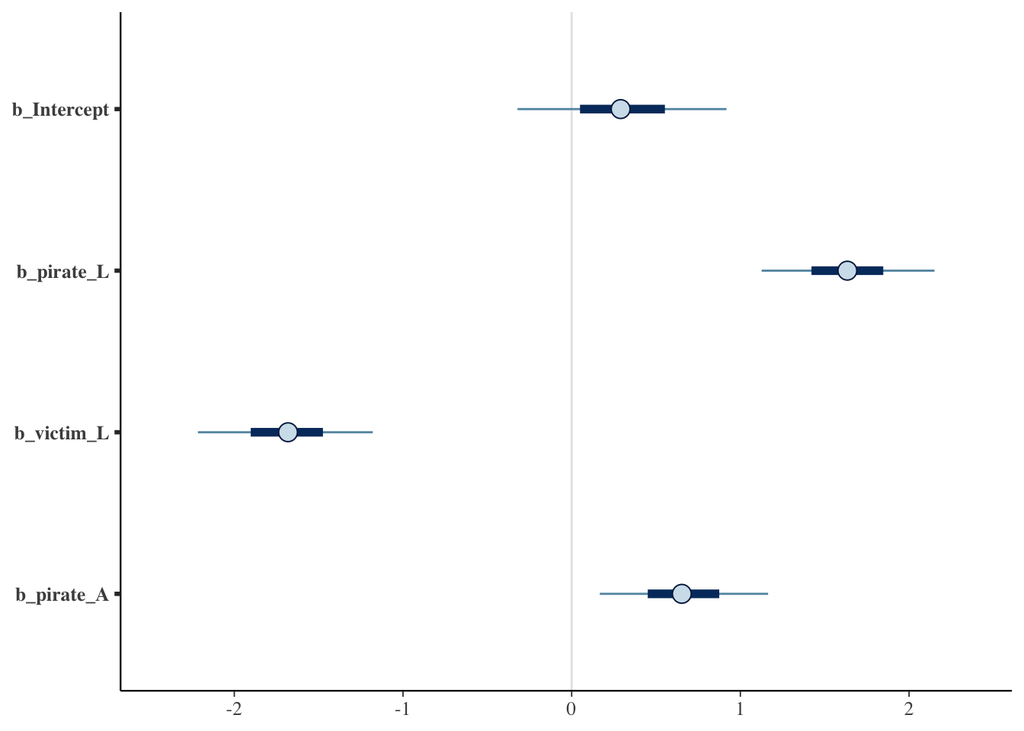

```r
mcmc_plot(b11.h2, pars = "^b_")
```

The approximation does look ok. Our chains look like fuzzy caterpillar, meaning that they explore the parameter space well, and Rhat values are all = to one, indicating model convergence.

### Q11H2b

Then plot the posterior predictions. Compute and display both (1) the predicted probability of success and its 89% interval for each row (i) in the data, as well as (2) the predicted success count and its 89% interval. What different information does each type of posterior prediction provide?

```r
# determine the range of `a` values we'd like to feed into `fitted()`
nd <-
  data %>%
  distinct(y, n, pirate_L, victim_L, pirate_A)

# predictions of the responses
predict(b11.h2)
```

```
##      Estimate Est.Error   Q2.5 Q97.5
## [1,] 16.94500  2.668287 11.975    22
## [2,] 26.85800  1.577326 23.000    29
## [3,] 15.12725  3.127939  9.000    21
## [4,] 17.31600  1.731154 13.000    20
## [5,]  3.93525  1.781390  1.000     8
## [6,] 11.44000  2.119085  7.000    15
## [7,]  5.74700  2.540198  1.000    11
## [8,]  2.28875  1.039059  0.000     4
```

```r
# predictions of the regression line
fitted(b11.h2)
```

```
##       Estimate Est.Error      Q2.5     Q97.5
## [1,] 16.949058 1.4778887 13.861430 19.652452
## [2,] 26.871534 0.6955029 25.289144 27.961978
## [3,] 15.059253 1.8556039 11.504740 18.562713
## [4,] 17.356121 0.8243430 15.497696 18.700101
## [5,]  3.930112 0.8614337  2.412300  5.711737
## [6,] 11.462342 1.1523487  9.101672 13.495382
## [7,]  5.684167 1.4198942  3.230353  8.802517
## [8,]  2.284249 0.3559174  1.560579  2.945493
```

```r
 (post_predict <- fitted(b11.h2,
         newdata = nd) %>%
  data.frame() %>%
  bind_cols(nd) %>%
     mutate(row = row_number(),
            predicted_prob = (Estimate / n)))
```

```
##    Estimate Est.Error      Q2.5     Q97.5  y  n pirate_L victim_L pirate_A row
## 1 16.949058 1.4778887 13.861430 19.652452 17 24        1        1        1   1
## 2 26.871534 0.6955029 25.289144 27.961978 29 29        1        0        1   2
## 3 15.059253 1.8556039 11.504740 18.562713 17 27        1        1        0   3
## 4 17.356121 0.8243430 15.497696 18.700101 20 20        1        0        0   4
## 5  3.930112 0.8614337  2.412300  5.711737  1 12        0        1        1   5
## 6 11.462342 1.1523487  9.101672 13.495382 15 16        0        0        1   6
## 7  5.684167 1.4198942  3.230353  8.802517  0 28        0        1        0   7
## 8  2.284249 0.3559174  1.560579  2.945493  1  4        0        0        0   8
##   predicted_prob
## 1      0.7062107
## 2      0.9266046
## 3      0.5577501
## 4      0.8678060
## 5      0.3275093
## 6      0.7163964
## 7      0.2030060
## 8      0.5710623
```

```
## geom_path: Each group consists of only one observation. Do you need to adjust
## the group aesthetic?
```

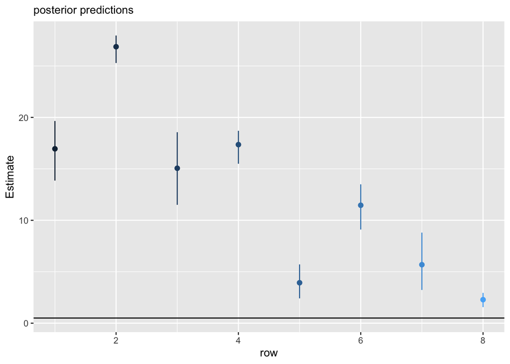

```r
   #  pivot_longer(pirate_L:pirate_A) %>%
     #rename(variable = name) %>%
  #mutate(condition = factor(condition)) %>%

  ggplot(data = post_predict, aes(x = row, y = Estimate, ymin = Q2.5, ymax = Q97.5)) +
  geom_hline(yintercept = .5) +
  geom_line(aes(group = row),
            size = 1/4) +
  geom_pointrange(aes(color = row),
                  fatten = 2.5, show.legend = F) +
  labs(subtitle = "posterior predictions")
```

*Similarly to as what Christen posted in her moodel post, I am unsure how to calculate the 89% CI intervals for aggregated proportion, without running a new model?*

What different information does each type of posterior prediction provide

Conceptually though the posterior prediction from the count column provides a relative assessment of success, were as the proportion column is in absolute terms

### Q11H2c

Now try to improve the model. Consider an interaction between the pirate’s size and age (immature or adult). Compare this model to the previous one, using WAIC. Interpret.

```r
b11.h2c.p <-
  brm(data = data,
      family = binomial,
      y | trials(n) ~ 1 + pirate_L + victim_L + pirate_A + pirate_L:pirate_A,
      prior = c(prior(normal(0, 1.5), class = Intercept),
                prior(normal(0, 0.5), class = b)),
      iter = 2000, warmup = 1000, chains = 4, cores = 4,
      seed = 11)


b11.h2c.v <-
  brm(data = data,
      family = binomial,
      y | trials(n) ~ 1 + pirate_L + victim_L + pirate_A + pirate_L:victim_L,
      prior = c(prior(normal(0, 1.5), class = Intercept),
                prior(normal(0, 0.5), class = b)),
      iter = 2000, warmup = 1000, chains = 4, cores = 4,
      seed = 11)
```

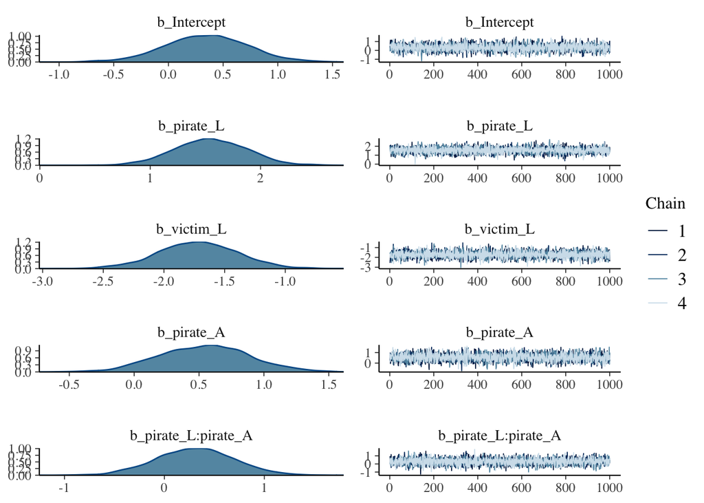

```r
plot(b11.h2c.p)
```

```r
summary(b11.h2c.p)
```

```
##  Family: binomial
##   Links: mu = logit
## Formula: y | trials(n) ~ 1 + pirate_L + victim_L + pirate_A + pirate_L:pirate_A
##    Data: data (Number of observations: 8)
## Samples: 4 chains, each with iter = 2000; warmup = 1000; thin = 1;
##          total post-warmup samples = 4000
##
## Population-Level Effects:
##                   Estimate Est.Error l-95% CI u-95% CI Rhat Bulk_ESS Tail_ESS
## Intercept             0.35      0.38    -0.40     1.09 1.00     3956     2933
## pirate_L              1.55      0.33     0.91     2.20 1.00     4335     2994
## victim_L             -1.72      0.33    -2.37    -1.08 1.00     4564     3027
## pirate_A              0.54      0.34    -0.11     1.22 1.00     3825     2966
## pirate_L:pirate_A     0.31      0.39    -0.45     1.07 1.00     3989     3137
##
## Samples were drawn using sampling(NUTS). For each parameter, Bulk_ESS
## and Tail_ESS are effective sample size measures, and Rhat is the potential
## scale reduction factor on split chains (at convergence, Rhat = 1).
```

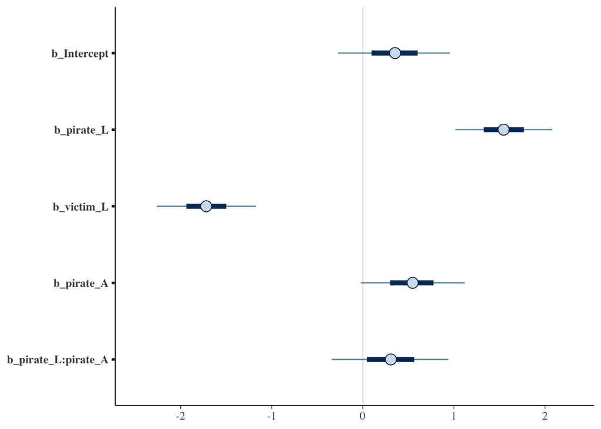

```r
mcmc_plot(b11.h2c.p, pars = "^b_")
```

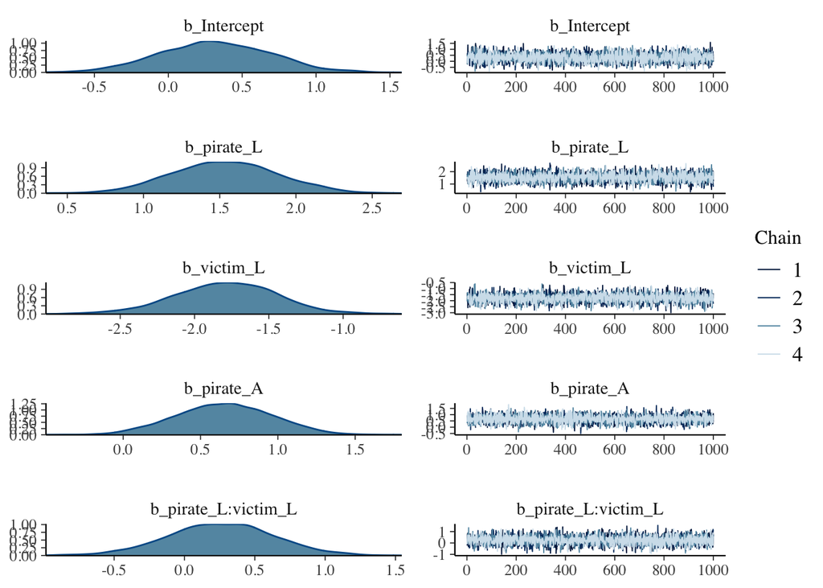

```r
plot(b11.h2c.v)
```

```r
summary(b11.h2c.v)
```

```
##  Family: binomial
##   Links: mu = logit
## Formula: y | trials(n) ~ 1 + pirate_L + victim_L + pirate_A + pirate_L:victim_L
##    Data: data (Number of observations: 8)
## Samples: 4 chains, each with iter = 2000; warmup = 1000; thin = 1;
##          total post-warmup samples = 4000
##
## Population-Level Effects:
##                   Estimate Est.Error l-95% CI u-95% CI Rhat Bulk_ESS Tail_ESS
## Intercept             0.32      0.37    -0.40     1.05 1.00     4602     3012
## pirate_L              1.54      0.34     0.87     2.20 1.00     3872     3212
## victim_L             -1.79      0.34    -2.49    -1.12 1.00     4573     3094
## pirate_A              0.65      0.31     0.05     1.24 1.00     4891     2651
## pirate_L:victim_L     0.26      0.37    -0.49     1.00 1.00     4257     3169
##
## Samples were drawn using sampling(NUTS). For each parameter, Bulk_ESS
## and Tail_ESS are effective sample size measures, and Rhat is the potential
## scale reduction factor on split chains (at convergence, Rhat = 1).
```

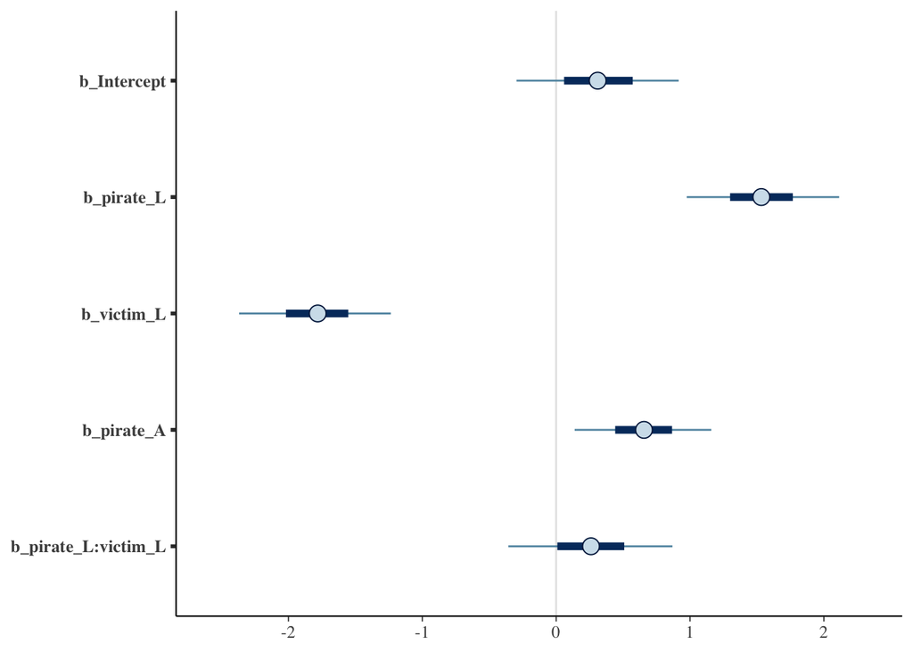

```r
mcmc_plot(b11.h2c.v, pars = "^b_")
```

```r
b11.h2 <- add_criterion(b11.h2, criterion = "waic")
b11.h2c.p <- add_criterion(b11.h2c.p, criterion = "waic")
b11.h2c.v <- add_criterion(b11.h2c.v, criterion = "waic")
```

```
## Warning:
## 5 (62.5%) p_waic estimates greater than 0.4. We recommend trying loo instead.
```

```r
b_waic <- loo_compare(b11.h2, b11.h2c.p, b11.h2c.v, criterion = "waic")

print(b_waic, simplify = F)
```

```
##           elpd_diff se_diff elpd_waic se_elpd_waic p_waic se_p_waic waic
## b11.h2c.v   0.0       0.0   -29.3       5.6          8.4    2.8      58.5
## b11.h2     -0.3       0.9   -29.5       6.1          8.3    3.0      59.0
## b11.h2c.p  -1.4       1.3   -30.6       6.4          9.3    3.1      61.2
##           se_waic
## b11.h2c.v  11.2
## b11.h2     12.2
## b11.h2c.p  12.8
```

I received warning messages that p_waic exceed the recommended threshold, and thus attempted the same using loo

```r
b11.h2 <- add_criterion(b11.h2, criterion = "loo")
```

```
## Warning: Found 3 observations with a pareto_k > 0.7 in model 'b11.h2'. It is
## recommended to set 'moment_match = TRUE' in order to perform moment matching for
## problematic observations.
```

```r
b11.h2c.p <- add_criterion(b11.h2c.p, criterion = "loo")
```

```
## Warning: Found 4 observations with a pareto_k > 0.7 in model 'b11.h2c.p'. It is
## recommended to set 'moment_match = TRUE' in order to perform moment matching for
## problematic observations.
```

```r
b11.h2c.v <- add_criterion(b11.h2c.v, criterion = "loo")
b_loo <- loo_compare(b11.h2, b11.h2c.p, b11.h2c.v, criterion = "loo")

print(b_loo, simplify = F)
```

```
##           elpd_diff se_diff elpd_loo se_elpd_loo p_loo se_p_loo looic se_looic
## b11.h2c.v   0.0       0.0   -30.2      5.9         9.3   3.1     60.3  11.8
## b11.h2     -0.7       1.2   -30.9      6.8         9.7   3.7     61.8  13.6
## b11.h2c.p  -1.9       1.4   -32.0      6.7        10.7   3.4     64.0  13.4
```

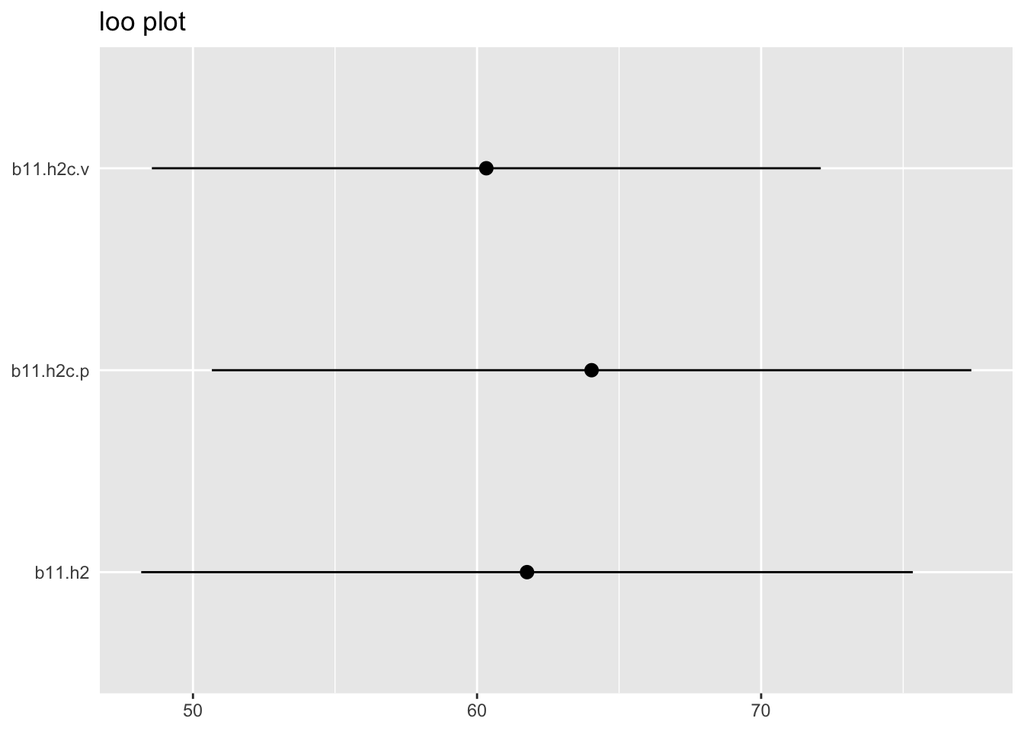

```r
b_loo[, 7:8] %>%
  data.frame() %>%
  rownames_to_column("model_name") %>%

  ggplot(aes(x = looic, y = model_name,
             xmin = looic - se_looic,
             xmax = looic + se_looic)) +
  geom_pointrange() +
  labs(title = "loo plot",
       x = NULL, y = NULL) +
  theme(axis.ticks.y = element_blank())
```